# 1 Behavioural responses to advice contexts

Advice-taking can be contingent on the properties of the advice, or on the properties of the advisor. In order to maximise the value of advice while minimising the potential exposure to exploitation, advice-taking should be contingent on a combination of these factors. Where advice is plausible it should be weighted relatively equally, whether it comes from an advisor who is sometimes misleading or not, but where advice is more implausible it should only be trusted when it comes from an advisor who is never misleading.

To explore whether people’s behaviour matches this pattern, participants were recruited for a series of behavioural experiments in which they were given advice on a date estimation task from advisors who were described as either always helpful or occasionally misleading. Results indicated that participants’ advice-taking depended upon both the plausibility of the advice and the benevolence of the advisor, although the specific pattern differed from the one described above.

## 1.1 Method

### 1.1.1 Paradigm

The core paradigm for these experiments is the dates estimation task, described previously. Additionally, in this version, participants had to provide an assessment of the honesty of each advisory estimate they received before they could integrate it into their final decision.

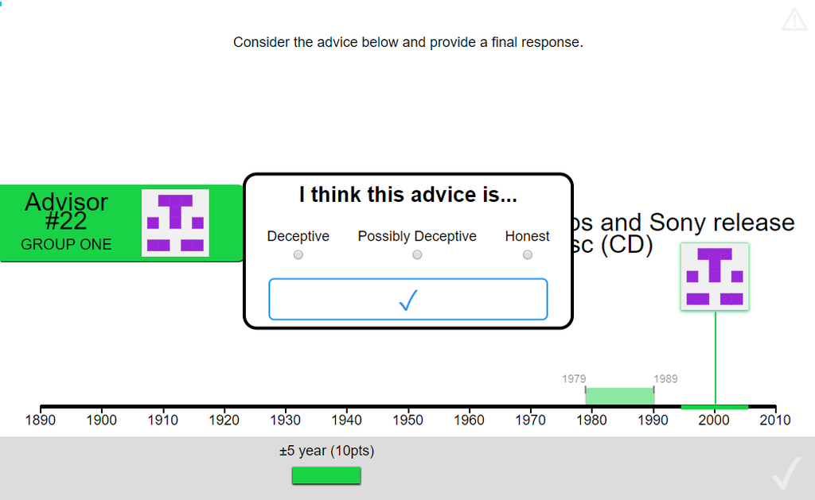

Figure 1.1: Advice honesty rating: participants rated advice on a three-point scale according to whether they thought the advice was deceptive or honest.

### 1.1.2 Manipulation

Participants performed two blocks of experimental trials. In one block, participants received advice from an advisor who they were told would ‘always try to help’, while in the other they received advice from an advisor who ‘may sometimes try to mislead’. The order of advisors was counterbalanced between participants.

The advice offered by the advisors was drawn from equivalent distributions for both advisors, meaning that there were no systematic differences in the quality of the advice. Both advisors offered advice sampled from a roughly normal distribution around the correct answer with a standard deviation of 11 years.

### 1.1.3 Experiments

There were a series of experiments in this topic during which the experimental design was tweaked in order to find an effective manipulation and operationalisation of the key concepts. The experimental code for previous versions can be found on the commit history on GitHub for the [main experimental file](https://github.com/oxacclab/ExploringSocialMetacognition/commits/master/ACv2/db.html), as well as its [dependencies](https://github.com/oxacclab/ExploringSocialMetacognition/commits/master/src/modules).

To give a brief overview of the major changes:

- Version 2.0.0
  - introduced a much clearer manipulation
    - reminded participants of advisor description in a message they had to acknowledge
    - kept participant’s group visible throughout
    - included a single trial where the misleading advisor did actually mislead the participant
- Version 2.1.0
  - removed actual differences in advice and adjusted advisor descriptions to match
- Version 3.0.0
  - added a question probing the perceived honesty of the advice between receiving advice and providing a final decision
- Version 3.0.1
  - [pre-registered](https://osf.io/tu3ev) replication of V3.0.0
  - Deviations from pre-registration:
    - Added a new exclusion rule for those people who use translation software.
    - Added exclusions for participants with NA values in the in- vs out-group t-test (where e.g. no outgroup advice was rated as ‘honest’).
    - Included frequentist stats in the trustworthiness questionnaire item t-test.
    - Fixed some labels on graphs
    - Exploratory analyses expanded to include analysis of trials with WoA > .05

## 1.2 Results

### 1.2.1 Exclusions

Participants (total *n* = 20) could be excluded for a number of reasons: failing attention checks, having fewer than 11 trials which took less than 1 minute to complete (one participant), providing final decisions which were the same as the initial estimate on more than 90% of trials, or using non-English labels for the honesty questionnaire (one participant). The latter exclusion was added after data were collected because it was not anticipated that participants would use translation software in the task.

The final participant list consists of 18 participants who completed an average of 11.83 trials each.

### 1.2.2 Task performance

Participants performed as expected, decreasing the error between the midpoint of their answer and the true answer from the initial estimate to the final decision, which suggests that they incorporated the advice, which was indicative of the correct answer.

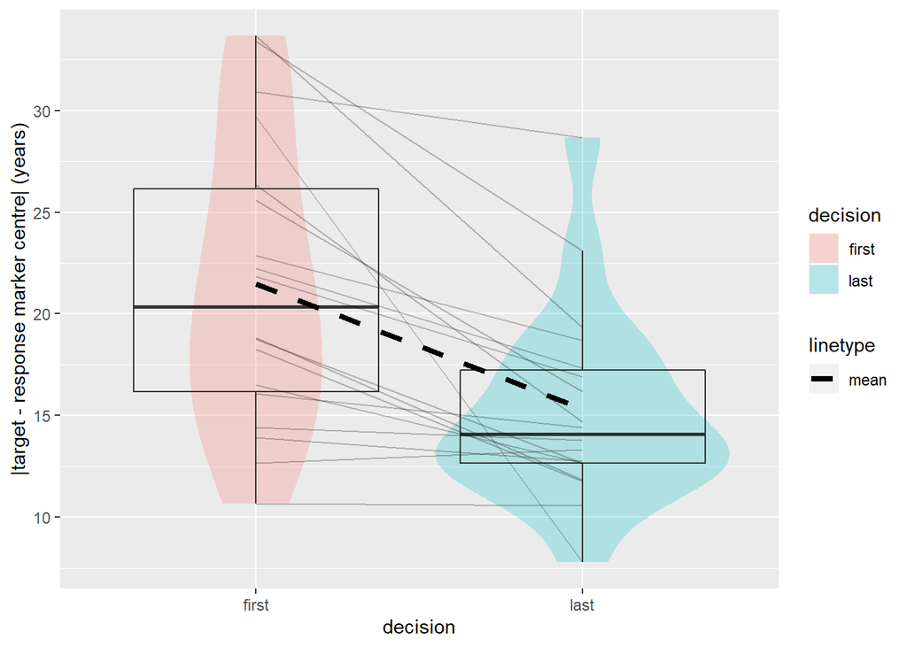

Figure 1.2: Mean answer error for initial estimates and final decisions. Faint lines show means for individual participants collapsed across trials, while boxplots, violins, and the heavy dashed line show aggregate participant means.

The advice participants received was subject to variation, but there did not appear to be overall systematic differences between the advisors either in terms of error (distance between the centre of the advice estimate and the correct answer) or distance (distance between the centre of the advice estimate and the centre of the initial estimate).

### 1.2.3 Hypotheses

The hypotheses tested were that * weight on advice would be higher for advice rated as ‘honest’ versus advice rated as ‘deceptive’ * weight on advice would be higher for advisors who were described as ‘never misleading’, even for advice rated as ‘honest’

#### 1.2.3.1 Effect of advice

```r
tmp <- AdvisedTrial %>%
  dplyr::filter(advisor0questionnaireHonestyLabel %in%
                  c('Honest', 'Deceptive')) %>%
  group_by(
    pid,
    advisor0questionnaireHonestyLabel
  ) %>%
  summarise(woa = mean(advisor0woa, na.rm = T)) %>%
  # strip missing cases
  spread(advisor0questionnaireHonestyLabel, woa) %>%
  dplyr::filter_all(all_vars(!is.na(.)))

r <- md.ttest(tmp$Deceptive, tmp$Honest,
              c('*M*|deceptive', '*M*|honest'),
              paired = T)
```

As expected, participants were substantially more influenced by advice they rated as ‘honest’ compared to advice they rated as ‘deceptive’ (*t*(10) = -5.01, *p* < .001, *d* = 1.55, BF = 69.66; *M*|deceptive = 0.18 [-0.04, 0.41], *M*|honest = 0.62 [0.47, 0.77]).

#### 1.2.3.2 Effect of advisor

```r
tmp <- AdvisedTrial %>%
  dplyr::filter(advisor0questionnaireHonestyLabel == 'Honest') %>%
  group_by(pid, advisor0idDescription) %>%
  summarise(woa = mean(advisor0woa)) %>%
  spread(advisor0idDescription, woa) %>%
  dplyr::filter_all(all_vars(!is.na(.)))


r <- md.ttest(tmp$inGroup, tmp$outGroup,
              c("*M*|inGroup", "*M*|outGroup"), paired = T)
```

Participants were also more influenced by ‘honest’ advice from the advisor who was described as ‘never misleading’ (*t*(15) = 2.63, *p* = .019, *d* = 0.68, BF = 3.22; *M*|inGroup = 0.64 [0.51, 0.77], *M*|outGroup = 0.46 [0.30, 0.61]).

#### 1.2.3.3 Results plot

The details of the data are best presented in a combined figure.

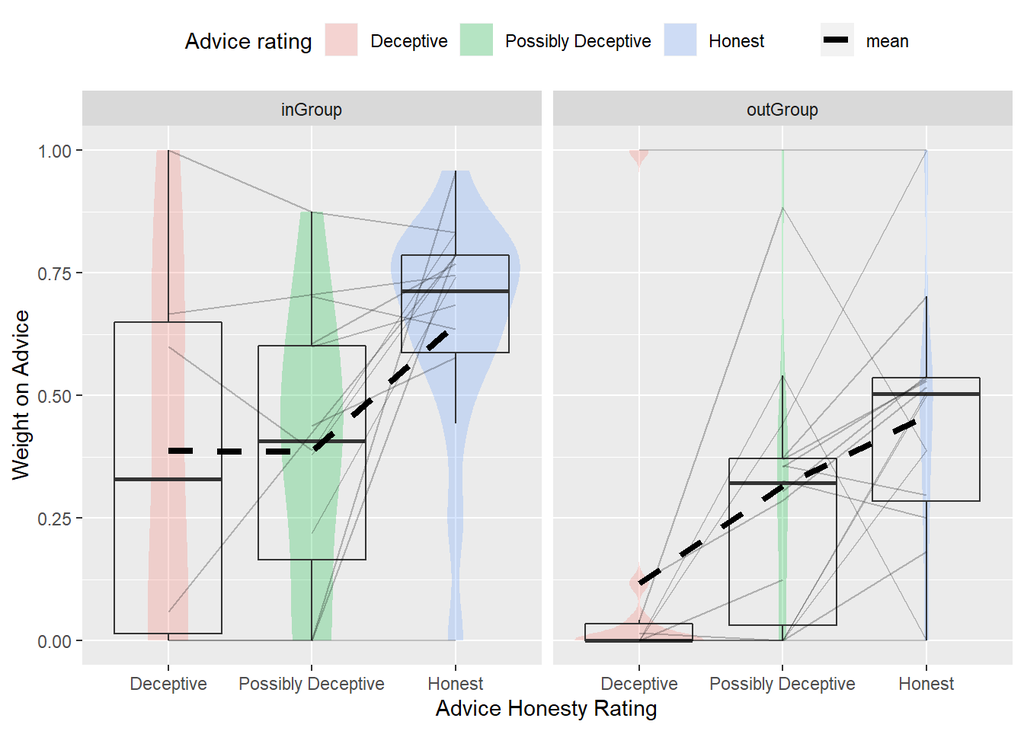

Figure 1.3: Influence of advice by advisor according to participants’ perception of advice honesty. Faint lines show means for individual participants (missing segments indicate the participant rated no advice from that advisor with the designated category). Violins, box plots, and heavy dashed lines aggregate means for all participants.

The figure shows that there is a different pattern in the responses to advice across advice ratings depending upon the advisor supplying the advice. Advice perceived as not being honest is discounted relatively equally from the advisor described as ‘always helpful’, and is still fairly influential in the final decision. The advice perceived as ‘honest’ from this advisor is the most influential of all advice. Likewise, the ‘honest’ advice from the advisor described as ‘sometimes-misleading’ is more influential than the ‘possibly deceptive’ advice, which is in turn more influential than the ‘deceptive’ advice. The ‘deceptive’ advice from the ‘sometimes-misleading’ advisor is almost completely ignored.

Within this broader pattern there is some variability between participants, including some participants whose responses violate the pattern quite dramatically - note the two participants with large decreases in influence for ‘honest’ advice from the ‘sometimes-misleading’ advisor as compared to the ‘possibly deceptive’ advice from the same. This may be a consequence of participants’ values in each cell in the design being comprised of a low number of trials.

## 1.3 Discussion